# R to Moodle XML

A survey

I Joly

13/05/2019

Ce document présente le package `Rexams` permettant de créer un qcm et de l’importer simplement dans Moodle (Caseine).

# Tests Moodle-Caseine écrits avec RStudio

## Introduction

### Complémentarités Moodle et R

La combinaison de R et de Moodle permet de tirer profit de leurs complémentarités. En effet, ils ont adopté un même standard de fichier pour les qcm : `xml`.

Le package `Rexams` de R permet d’écrire les questions (avec réponse et corrigé) dans un format compatible avec Moodle: format `xml`.

Ainsi, on peut rédiger ses questions sous RStudio **en local**. Les stocker, les organiser, les modifier, en local.

Puis les exporter vers Moodle ; aussi simplement que vers pdf, word, html, ppt, etc. !

> RStudio: vers une plateforme unique de génération de documents dynamiques !

### Points forts de Moodle

Avec un peu d’expérience sur Moodle, on découvre rapidement les possibilités offertes et à structurer des qcm, les exercices, et les questions en fonction de ces possibilités.

1. Les possibilités de structure des qcm de Moodle permettent
- d’écrire plusieurs questions successives pour former un exercice
- inutile alors de forcer une question à tout faire !

**MAIS** cela implique que + c’est une question fixe et identique pour tous (pas de tirage aléatoire de la question) + Les questions apparaissent dans des blocs séparés.

> *Il est recommandé d’explorer Caseine et de tester l’importation de fichiers avant d’écrire ses 1ères questions sous R*

## Configurer un test Moodle-Caseine

### Importation du fichier xml depuis Moodle-Caseine

On importe un fichier d’extension `xml`. il peut contenir soit:

- une seule question: on importe alors uniquement cette question.
- une serie de questions: on importe une succession de questions, qui vont donc apparaître dans la banque de questions de Moodle comme une série d’exercices.  
  Cette série de questions peut constituer un exercice (de plusieurs questions). Un ordre entre les questions doit être respecter. Les questions sont importees dans l’ordre du fichier `xml`.
- un test complet: on importe toutes les questions d’un test d’un bloque et Moodle les importe dans l’ordre du fichier `xml`. On peut ensuite changer l’ordre, intégrer de l’aléa dans sur tout ou partie de l’ordre des questions, etc.

Caseine crée alors un groupe de question, un label, sous lequel sont regroupées la ou les question(s) importées.

On peut ensuite faire appel au groupe de questions entier ou à chaque question dans le groupe selon les besoins.

**Remarques**

> Attention : on peut charger un test entier (plusieurs questions).

> Elles apparaîssent dans un même groupe.

> Caseine crée un label pour chaque tentative d’importation. On n’écrase pas les questions ou labels de même nom. Il conserve donc chaque version importée.

> à chaque chargement du fichier `.Xml` on créé un nouveau groupe: les questions sont dupliquées, *elles ne remplacent pas les précédentes*.

> Attention à l’usage de certains éléments bloquant l’import : ex. `\mathcal{}`

### Sous Caseine

- On ajoute une question dans la `Banque de questions`: espace commun aux cours de l’enseignant.
- A partir de la `Banque de Questions`
- Onglet `Importer`
- sélectionner le format `Xml`
- sélectionner le fichier d’extension`.Xml`
- Cela créé un ‘groupe’ dans la banque (une sorte de tiroir)
- Ce ‘groupe’ $\neq$ `catégorie`
- Les questions sont à ajouter : à partir du test : “ajouter depuis la `Banque de Questions`”

### Configuration du test

Moodle-Caseine permet de créer des *sections* dans un test. Une section regroupe plusieurs questions. Dans une même section les questions seront traitées de la même façon (tirage aléatoire, conditions d’affichage, etc.)

- Structure par section
  - permet des questions successives pour constituer un exercice
  - permet de faire des tirages aléatoires de questions dans un groupe ou `catégorie` de question
- Possibilité de préciser les changements de pages entre certaines sections
- Possibilité de préciser les titres de sections

### Quelques exemples d’usages

1. Il peut être utile de créer dans un test, une 1ère section contenant des questions non évaluées de rappel des consignes (par ex:)
- règles d’arrondis
- niveau de tolérance
- reconnaissance des décimales `,` comme des `.`
- attention au `%`
- questions à points négatifs
- rappel de cloture du test
- éventuellement remise de copies si une partie des réponses est sur feuille

> Le reste des paramètrages se réalise sur Moodle-Caseine

Notamment

- la visibilité du questionnaire, le type de retour fait à l’étudiant (score, réponse, commentaires, etc)

## R Exams package

Pour une **première utilisation** de `R-Exams`

- Installation: `install.packages("exams")`
- Documentation: http://www.r-exams.org/

Lors des utilisations ultérieures l’installation n’est plus nécessaire, mais le package doit être chargé en mémoire à chaque session

- Chargement en session : `library("exams")`

## Organisation du projet

- Un projet de test est composé de
  1. Un fichier générateur du test (`R2M.R`)
  2. Un fichier par question du test (`Q1.Rmd`, `Q2.Rmd`)

> Prendre l’habitude d’encoder dans un même format par ex `UTF8`

> Gérer et organiser son espace de stockage des fichiers:
- par ex: un dossier avec toutes les questions du test  
  on les chargera toutes d’un bloc dans le test
- un dossier par groupe de questions sur un même sujet  
  on piochera dans les dossiers la ou les questions choisies pour le test

#### 1. Dn fichier `.R` générateur du QCM

- Il prend en entrèes les fichiers questions `.Rmd`
- Il créé en sortie un fichier `.Xml`
- Quelques options sont possibles au niveau questionnaire (d’autres dans les fichiers questions)
  - `dir = mydir`: output directory
  - `name = "Test_QCM_JAX"`: nom du fichier et du test
  - `encoding = "UTF8"` : Encodage `UTF8`
  - `converter = "pandoc-mathjax"`: Choix de l’encodage des équations (compatibles avec *chrome*)
- Stratégie de localisation des fichiers:
  - Il peut être placé directement dans le dossier qui contient les questions. Option la plus simple pour un chargement en bloc des questions.
  - Il peut être placé ailleurs et préciser la localisation des questions

#### 2. Des fichiers `.Rmd`ou `.Rnw` par question

Le générateur de test d’extension `.R` précédent utilise

- un fichier pour une question (avec solution & corrigé)
- autant de fichiers que de questions dans le QCM

Les fichiers questions se caractérisent par :

- Format `Rmd`plus simple.
- Format `Rnw` plus proche de LaTeX, donc plus de paramètres.
- une structure de fichier à respecter
- une structure stable pour tout type de questions
- plusieurs niveaux d’usage possibles des fonctionnalités `R`
  1. Ecrire ses propres questions
  2. Programmer ses propres questions
  3. Programmer la personnalisation des questions

## Préparation du fichier générateur du QCM `.R`

Les lignes suivantes peuvent être reprises et adaptées.

Elles constituent l’équivalent d’un document *maitre* (le fichier de test réunissant les questions) qui fait référence, utilise et assemble des *sous-documents* (un sous-document pour chaque question du test)

### Version 1

Où on définit un dossier de travail contenant tout : `.R`, `.Rmd` et `.Xml`

```r
#
options(device.ask.default = FALSE)
## Working directory
setwd("C:\\Users\\ijoly.INRA\\Desktop\\ExamStat2019\\Exo_OK")
## Output directory
mydir <- ("C:\\Users\\ijoly.INRA\\Desktop\\ExamStat2019\\Exo_OK")
```

### Préparation du fichier générateur du QCM

Où l’on crée un fichier `Xml` pour Moodle et un fichier `.html` par des fonctions similaires `exams2moodle` et `exams2html`

```r
## XML
exams2moodle(file =list("EX01_FR.Rmd")  , dir = getwd(), name = "test_demo", encoding = "UTF8")
## HTML
exams2html(file =list("EX1_FR.Rmd", "EX02_FR.Rmd")  , dir = mydir, name = "test_demo", encoding = "UTF8")
```

On précise les arguments

- `file=`: la liste des fichiers de questions
- `dir=` : le dossier contenant les questions et le résultat `Xml`
- `name=`: le nom du fichier `.Xml`
- `encoding=` : l eformat d’encodage des caratères. Le standard `UTF8` est recommandé.

### Version 2

Où on définit un dossier que l’on scanne pour lister tous les fichiers *inputs* des questions `.Rmd`.

```r
#
options(device.ask.default = FALSE)
## Working directory
setwd("C:\\Users\\ijoly.INRA\\Desktop\\ExamStat2019\\Exo_OK")
## Output directory
mydir <- ("C:\\Users\\ijoly.INRA\\Desktop\\ExamStat2019\\Exo_OK")
## Listing/content of mydir
myqcm <- dir(mydir);myqcm
```

[output not shown]

```r
myexo <- list.files(path =mydir, pattern = ".Rmd")
```

### Préparation du fichier générateur du QCM

Où on charge la liste de fichiers questions `Rmd`

- `n=` : indique le nombre de copies du test à produire

```r
## XML
exams2moodle(file = myexo ,   n = 1, dir = mydir, name = "Test_QCM",
              encoding = "UTF8")
```

## Préparation du fichier question `Rmd`

```r
Question
========
Answerlist
----------
* item

Solution
=========
Answerlist
----------
* item

Meta-information
================
exname: Titre
extype: schoice
exsolution: 00100
exshuffle: TRUE
```

### La question

- La question est faite de 2 balises identifiant la question (`Question`) et les propositions de réponses (quand il y en a) (`Answerlist`)

```r
Question
========
On écrit ici sa question...

Answerlist
----------
* une première proposition de réponse
* une seconde proposition de réponse
* ...
```

- l’ordre des propositions pourra être aléatoire lors de l’affichage aux apprenants
- l’ordre des propositions est à respecter pour la rédaction des réponses, commentaires, etc.

Rque:

- Je n’ai pas encore trouvé comment gérer une numérotation ou une autre (a., b., c. ou 1), 2), 3))
- Pour une question à réponse numérique, la liste de proposition est inutile et donc omise

### La Solution

La solution ou le corrigé sont précisés après la balise `Solution`. En présence de liste de propositions, il convient de conserver l’ordre des propositions dans `Answerlist`.

```r
Solution
=========

On rédige ici une solution

Answerlist
----------
* On précise ici pour chaque proposition la solution ou le commentaire
* corrigé suivant...
* ...
```

Rque:

- Les bonnes réponses sont précisées dans la balise `Metainformation`
- Le passage à Caséine nécessite un peu de pratique ici.  
  Selon les options que l’on choisit pour le corrigé retourné à l’apprenant, les propositions sont affichées, puis les bonnes réponses, puis les commentaires ou corrigé.  
  Il ne paraît pas nécessaire de recopier le libellé de la proposition dans la solution.

#### Les Metainformations

Le type de questions et les paramètres de la question sont renseignés dans la balise `Metainformation`

```r
Meta-information
================
exname: Titre
extype: schoice
exsolution: 00100
exshuffle: TRUE
```

- `exname`: Le titre de la question (il n’apparaît pas ailleurs)
- `extype`: pour le type de question:
  - `schoice`: question à choix unique (ex: type vrai/faux)
  - `mchoice`: question à choix multiple (ex: plusieurs cases à cocher, dont les fausses sont à points négatifs)
  - `num`: question à réponse numérique. Une valeur est attendue $\pm$ tolérance
  - `cloze`: question à format varié. Peut inclure des réponses numériques et des réponses à choix multiples
- `exsolution`: bonnes réponses de la question.
  - son format varie selon le type de question
  - suite de 01 pour les `schoice` et `mchoice`
  - valeur numérique pour `num`
  - combinaison de `01| num`
- exshuffle: `TRUE` les propositions de réponses sont affichées mélangées

#### Question de choix simple: `schoice`

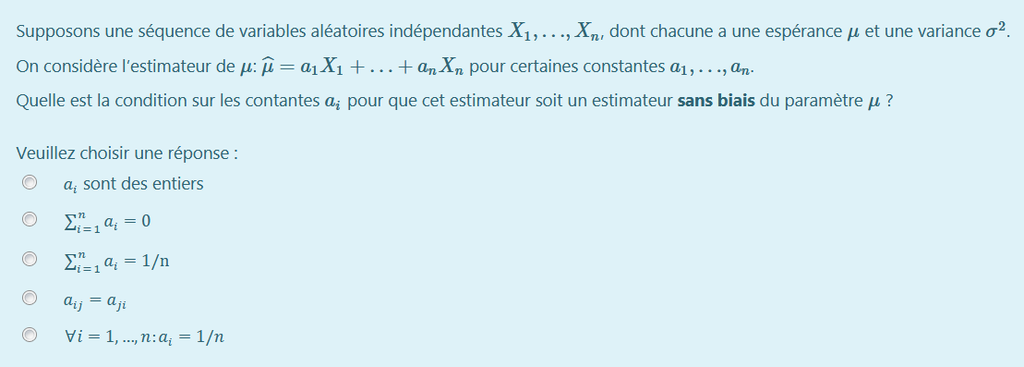

`schoice`

#### Question de choix multiple: `mchoice`

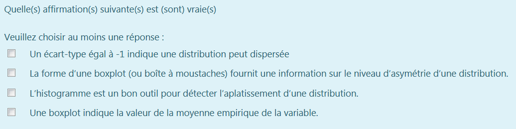

`mchoice`

#### Question numérique: `num`

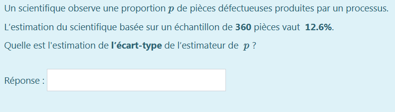

`num`

#### La question `num`

On pose la question

```r
Question
========
Quelle est la valeur ...
```

On donne le corrigé

```r
Solution
========
Pour calculer la valeur, il faut ...
```

On calibre la question avec la valeur attendue `exsolution` et la tolérance `extol`

`fmt(valeur,3)` met en format la valeur, avec 3 décimales

```r
Meta-information
================
extype: num
exsolution: `r fmt(valeur, 3)`
exname: constante c
extol: 0.02
```

#### Question mixant plusieurs types: `cloze`

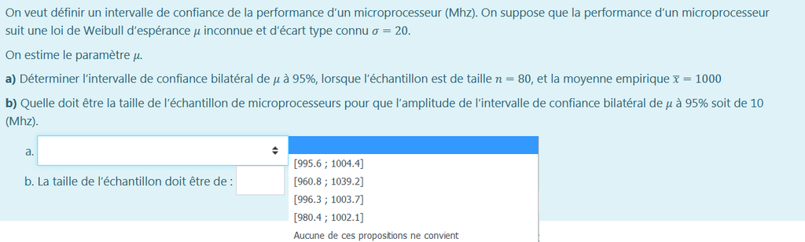

`cloze`

## Questions & problèmes irrésolus

1. Moodle
- Imprimer toutes les questions (avec leur corriger, commentaires, etc) en pdf
- Supprimer une proposition de réponse dans une QCM ? La case à cocher reste
2. R-Exams
- Indiquer le barême de la question
- Configurer les pages de questions, leurs titres, etc.
- Faire apparaître les identifiants des exercices ou leur titres pour les identifier simplement

## Remarques Génériques

- Vérifier les listes étudiants Caseine avec base élèves : par email, nom, prénom
- Faire un rappel de consignes:
  - bien valider la fin du test
  - règles d’arrondis
  - tolérance de valeur
  - points négatifs
  - %
- attention à la lisibilité des équations (`math_lm`) sous chrome vs firefox: voir option sous R
- L’export `csv` des résultats semble avoir un soucis d’encodage ?

### Comment on pouvait soumettre à la place d’un étudiant

Voici la procédure (il y a peut-être plus simple).

1. En tant que prof, aller modifier les paramètres du test :
- réouvrir le test (Temps > Fermer le test)
- autoriser une tentative supplémentaire (Note > Nb de tentatives)
- indiquer que la tentative complète la précédente (Comportement des questions > Chaque tentative complète la précédente)
2. Se connecter sous le nom de l’élève :
- cliquer sur son nom dans la liste des participants ou des tentatives
- Administration > Se connecter sous ce nom
3. Aller faire une nouvelle tentative… Au passage, on peut modifier des réponses au besoin, sinon on va directement à la fin et on valide.
4. Reprendre son identité normale et bien penser à annuler les paramètres du point 1), notamment la date de rendu.